# Simulation studies for mis-classification in non-probability surveys

Author

Maciej Beręsewicz

## Basic setup

Read the packages for the simulation studies

```r
library(simex) ## only confusion matrix is provided
library(augSIMEX) ## more advanced methods
library(nonprobsvy)
library(data.table)
```

## Simulation studies

### Simulation study #1

This is the first sumulation study for the project. In this simulation study I check the performance of MC-SIMEX method for mis-classification where at least one auxiliary variable is measured with error. Then I verify the case when the target variable is also measured with error.

#### Simulation with mis-classified auxiliary variables

##### Description

Here is the description for the simulation study

- $N=100000$ – finite population size
- $X_1$ – categorical variable with 3 levels: `c("S", "M", "L")` with probabilities `c(0.7, 0.2, 0.1)`. This variable may refer to the size of the business entity.
- $X_2 \sim \text{Bernoulli}(0.7)$ – categorical variable referring to business sector (say 1=private, 0=public).
- $X_3 \sim \text{Bernoulli}(0.5)$ – categorical variable referring to some characteristic that is equally distributed in the population.

I generate two samples:

- non-probability sample $S_A$ with inclusion generated from Bernoulli distribution with probabilities generated from the logistic distribution with linear part given by

$$-4 + 3 \times I(X_1 = \text{L})$$
and where the expected sample size is about 4,500.

- probability sample $S_B$ with 1,000 sample size selected using SRS.

Next, for each simulation run I introduce classification errors for $X_1$ and $X_2$ given the following confusion matrices which elements are $\pi_{ij} = P(X^* == k | X == k)$ where $k$ are levels

$$\Gamma_{X_1} = \begin{bmatrix}
0.8 & 0.1 & 0.05 \\
0.15 & 0.7 & 0.15\\
0.05 & 0.2 & 0.8
\end{bmatrix}$$
and

For this simulation study I am intereted in $\mu_Y$ which is population mean (share) of $Y$. In the simulation study I compare the following estimators:

- naive estimator $\mu_{Y}^{\text{Naive}}$ which is a sample mean based on non-probability sample,
- two estimators when no mis-classification is observed in non-probability sample:
  - inverse probability weighted (IPW) estimator with calibration constraints $\mu_{Y}^{IPW}$ on $X_1$, $X_2$ and $X_3$ where calibration is performed with totals estimated from the probability sample,
  - mass imputation (MI) estimator based on logistic regression $\mu_Y^{MI}$ using all auxiliary variables $X_1$, $X_2$ and $X_3$
- two estimators when mis-classification is observed for non-probability sample *only*:
  - IPW with mis-classification in $X_1$ and $X_2$ which is denoted as $\mu_{Y}^{IPW*}$
  - MI with mis-classification in $X_1$ and $X_2$ which is denoted as $\mu_{Y}^{MI*}$
- mass imputation estimator where mis-classification in $X_1$ and $X_2$ is corrected using MC-SIMEX method assuming that the confusion matrix is known. This estimator is denoted as $\mu_{Y}^{MC-MI}$.

##### Codes to run the simulation

In the code below I generate population data

```r
set.seed(12345)
N <- 100000  ## population size
n_b <- 1000 ## probability sample
X1 <- sample(c("S", "M", "L"), N, prob = c(0.7, 0.2, 0.1), replace = T) ## X1 variable
X1 <- factor(X1, c("S", "M", "L"))
X2 <- rbinom(N, 1, prob = 0.7) ## X2 variable
X2 <- factor(X2, 0:1, c("Pub", "Priv"))
X3 <- rbinom(N, 1, prob = 0.5) ## X3 variable
Y <- rbinom(N, 1, plogis(-1 + 0.5*(X1 == "L") + 0.5*(X2=="Priv") - X3)) ## target variable
pi_A <- plogis(-4 + 3*(X1 == "L")) ## selection to non-probability sample
pop_data <- data.frame(X1,X2,X3,Y,pi_A) ## population data frame
head(pop_data)
```

```
  X1   X2 X3 Y       pi_A
1  M Priv  1 0 0.01798621
2  M Priv  1 0 0.01798621
3  M Priv  1 1 0.01798621
4  M  Pub  0 1 0.01798621
5  S Priv  1 0 0.01798621
6  S  Pub  1 0 0.01798621
```

The known population mean of $Y$ is 26.25%.

Now, I set up the confusion matrices

```r
Gamma_X1 <- matrix(c(0.8,  0.1, 0.05,
                     0.15, 0.7, 0.15,
                     0.05, 0.2, 0.8), nrow = 3, byrow = T)

rownames(Gamma_X1) <- colnames(Gamma_X1) <- c("S", "M", "L")

Gamma_X2 <- matrix(c(0.8, 0.15,
                     0.2, 0.85), byrow = T, ncol = 2)

rownames(Gamma_X2) <- colnames(Gamma_X2) <- c("Pub", "Priv")
```

Code to run the simulation

```r
n_reps <- 100
results <- list()

for (b in 1:n_reps) {
  set.seed(b)
  if( b %% 20 == 0) print(b)
  ## probability sample
  sample_b <- pop_data[sample(1:N, n_b), ]
  sample_b$sample_w <- N/n_b
  sample_b_svy <- svydesign(ids=~1, weights = ~ sample_w, data=sample_b)

  ## nonprobability sample
  sample_a <- pop_data[rbinom(N, 1, pop_data$pi_A) == 1, ]

  # without error -----------------------------------------------------------
  est_ipw <- nonprob(selection = ~ X1 + X2 + X3,
                     data = sample_a,
                     svydesign = sample_b_svy,
                     target = ~ Y,
                     control_selection = controlSel(h = 1, est_method_sel = "gee"))

  est_mi <- nonprob(outcome = Y ~ X1 + X2 + X3,
                    data = sample_a,
                    svydesign = sample_b_svy,
                    family_outcome = "binomial")

  ## with errors
  sample_a_with_error <- sample_a

  ## generate errors
  class_erros <- misclass(data.frame(X1 = sample_a_with_error$X1,
                                     X2 = sample_a_with_error$X2),
                          list(X1=Gamma_X1, X2=Gamma_X2), k = 1)

  sample_a_with_error$X1  <- class_erros$X1
  sample_a_with_error$X2  <- class_erros$X2

  est_ipw_err <- nonprob(selection = ~ X1 + X2 + X3,
                         data = sample_a_with_error,
                         svydesign = sample_b_svy,
                         target = ~ Y,
                         control_selection = controlSel(h = 1, est_method_sel = "gee"))

  est_mi_err <- nonprob(outcome = Y ~ X1 + X2 + X3,
                        data = sample_a_with_error,
                        svydesign = sample_b_svy,
                        family_outcome = "binomial")

  ## naive model
  est_mi_err_naive <- glm(Y ~ X1 + X2 + X3, family = binomial, x = TRUE, y = TRUE,
                          data = sample_a_with_error)

  ## model parameters corrected by MC-SIMEX approach
  res_mi <- simex::mcsimex(model = est_mi_err_naive,
                           mc.matrix = list(X1 = Gamma_X1, X2 = Gamma_X2),
                           SIMEXvariable = c("X1", "X2"),
                           asymptotic = FALSE,
                           fitting.method   = "quadratic",
                           B = 50)

  results[[b]] <- data.frame(b,
                             mu_naive = mean(sample_a$Y),
                             mu_ipw = est_ipw$output$mean[1],
                             mu_mi = est_mi$output$mean[1],
                             mu_ipw_star = est_ipw_err$output$mean[1],
                             mu_mi_star = est_mi_err$output$mean[1],
                             mu_mc_mi = weighted.mean(predict(res_mi, sample_b_svy$variables, type = "response"),
                                                      weights(sample_b_svy)))

}
```

```
[1] 20
[1] 40
[1] 60
[1] 80
[1] 100
```

```r
results_df <- rbindlist(results)
```

Boxplots with the simulation results

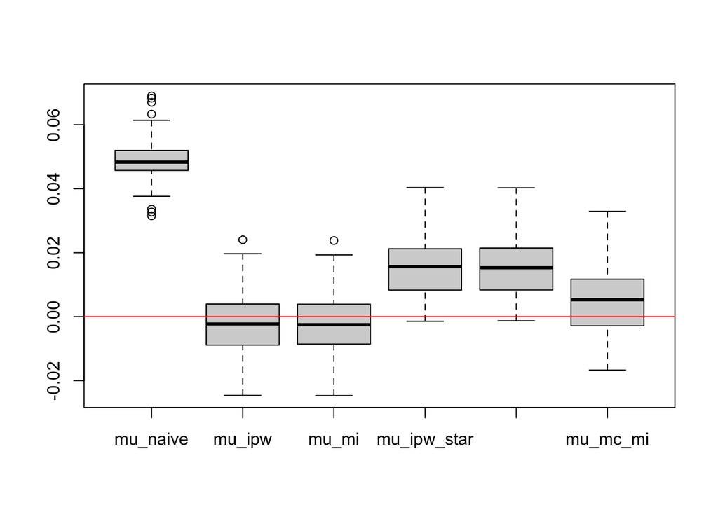

```r
boxplot(results_df[,-1]-mean(Y))
abline(a=0,b=0,h=1,col='red')
```

Bias, SD and RMSE

```r
results <- rbind(
  colMeans(results_df[,-1]) - mean(Y),
  apply(results_df[,-1], 2, sd),
  sqrt((colMeans(results_df[,-1]) - mean(Y))^2 + apply(results_df[,-1], 2, var))
)
rownames(results) <- c("bias", "SD", "RMSE")
as.data.frame(results)
```

```
        mu_naive       mu_ipw        mu_mi mu_ipw_star  mu_mi_star    mu_mc_mi
bias 0.049427704 -0.002224020 -0.002223028 0.016020389 0.015954946 0.005321416
SD   0.006836379  0.009957454  0.009934575 0.009475901 0.009471314 0.011199338
RMSE 0.049898236  0.010202801  0.010180257 0.018613048 0.018554409 0.012399300
```